# P/BIO381 Tutorials: Population Genomics 6: Testing selection using Fst outlier analysis

Mar 21, 2018

## Goals:

- **Understand** how local adaptation may lead to elevated allele frequency divergence among populations, estimated using Fst
- **Appreciate** the complications of population deomgraphy on using Fst as a selection statistic
- **Apply** a method (Bayescan) that detects the signature of local adaptation as elevated Fst at loci beyond the expected neutral distribution

### Challenges for finding Fst outliers:

As we’ve discussed in class, positive directional selection **acting differently across popuations** is expected to elevate genetic differentiation between groups (Fst).

- Fst measures *the magnitude of allele frequency differences between 2 or more groups*.
- BUT, neutral demographic history (genetic drift, bottlenecks, range expansions) can inflate Fst, leading to **false positives** in scans for selective sweeps.

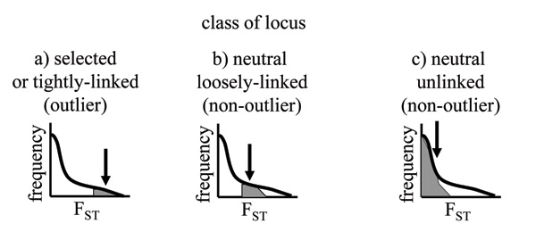

We’ll be using the program **‘Bayescan’** to test for SNPs with very high Fst, indicative of the action of diversifying selection and local adaptation. It is a method implemented by Matthieu Foll and Oscar Gaggiotti:

[Foll M and OE Gaggiotti (2008) A genome scan method to identify selected loci appropriate for both dominant and codominant markers: A Bayesian perspective. Genetics 180: 977-993](http://www.genetics.org/content/180/2/977)

Bayescan is a Bayesian method that estimates 2 key parameters:

- a population-specific effect (beta) that is shared among loci
- a locus-specific effect (alpha) that is shared among populations.

The **alpha** effect is the parameter that informs us about selection. Strong positive values indicate diversifying selection and local adaptation. Negative values indicate stablizing selection. Values close to zero are neutral.

#### OK, let’s get started:

- You need to first convert from vcf to Bayescan format using pgdspider. This takes a while, so we’re providing a converted file for you to use. You can find it here:

`/data/project_data/beetles/snps/OTAU_2018_reads2snps_DP10GP95_biallelic_MAF01_Miss0.8.vcf.recode.vcf.bayescan`

- To run Bayescan from the command line, you can either call the program with options, or write them into a bash script.
- To get an initial list of options, call the program without any inputs:

`[srkeller@pbio381 snps]$ bayescan`

| \| BayeScan 2.0 usage: \| |
| --- |
| -help Prints this help |

| \| Input \| |
| --- |
| alleles.txt Name of the genotypes data input file |
| -d discarded Optional input file containing list of loci to discard |
| -snp Use SNP genotypes matrix |

| \| Output \| |
| --- |
| -od . Output file directory, default is the same as program file |
| -o alleles Output file prefix, default is input file without the extension |
| -fstat Only estimate F-stats (no selection) |
| -all_trace Write out MCMC trace also for alpha paremeters (can be a very large file) |

| \| Parameters of the chain \| |
| --- |
| -threads n Number of threads used, default is number of cpu available |
| -n 5000 Number of outputted iterations, default is 5000 |
| -thin 10 Thinning interval size, default is 10 |
| -nbp 20 Number of pilot runs, default is 20 |
| -pilot 5000 Length of pilot runs, default is 5000 |
| -burn 50000 Burn-in length, default is 50000 |

| \| Parameters of the model \| |
| --- |
| -pr_odds 10 Prior odds for the neutral model, default is 10 |
| -lb_fis 0 Lower bound for uniform prior on Fis (dominant data), default is 0 |
| -hb_fis 1 Higher bound for uniform prior on Fis (dominant data), default is 1 |
| -beta_fis Optional beta prior for Fis (dominant data, m_fis and sd_fis need to be set) |
| -m_fis 0.05 Optional mean for beta prior on Fis (dominant data with -beta_fis) |
| -sd_fis 0.01 Optional std. deviation for beta prior on Fis (dominant data with -beta_fis) |
| -aflp_pc 0.1 Threshold for the recessive genotype as a fraction of maximum band intensity, default is 0.1 |

| \| Output files \| |
| --- |
| -out_pilot Optional output file for pilot runs |
| -out_freq Optional output file for allele frequencies |

- You’ve got lots of practice now writing simple bash scripts, so let’s have you try writing one on your own. Create a simple bash script that does the following:
1. Call the program
2. Tell it the input file (use the one in the shared space; no need to copy to ~/)
3. Specify the options you want
4. Direct the output to your `~/myresults/`

### Note:

- The most important option is `-pr_odds`
- This sets the prior probability on the odds that a given SNP is neutral vs. under selection. **The default value of 10 is generally much too low – that means 1 out of every 10 loci is under selection!** [Simulation studies that create SNP data under different models of gene flow and population structure reveal that this leads to many false positive SNPs](https://onlinelibrary.wiley.com/doi/full/10.1111/mec.12725).

[figure not shown]

- Let’s do an experiment to evaluate sensitivity of the results to the prior odds. Each student should **choose one** of the following values: `10, 100, 500, 1000, 5000, 10000`
- You may also want to specify an output directory to write all the results to. Be sure to **mkdir** this location ahead of time, or…you could write it into your bash script ;)
- Bayescan will run for a loooooong time, so before you execute your script, enter into a **screen**.
- Don’t forget to ctrl A + D to exit your screen before leaving class. We’ll look at the results next week!